# In-class exercise Week 5

Visualization using seaborn

### Imports

```python
import numpy as np
import scipy.stats as st
import pandas as pd
import matplotlib.pyplot as plt
import seaborn as sns
%matplotlib inline
```

## Data

Pokemon evolution dataset

```python
poke_original = pd.read_csv('pokemon.csv')
print (poke_original.shape)
poke_original.head()
```

```
(75, 27)
```

|  | name | species | cp | hp | weight | height | power_up_stardust | power_up_candy | attack_weak | attack_weak_type | ... | height_new | power_up_stardust_new | power_up_candy_new | attack_weak_new | attack_weak_type_new | attack_weak_value_new | attack_strong_new | attack_strong_type_new | attack_strong_value_new | notes |
| --- | --- | --- | --- | --- | --- | --- | --- | --- | --- | --- | --- | --- | --- | --- | --- | --- | --- | --- | --- | --- | --- |
| 0 | Pidgey1 | Pidgey | 384 | 56 | 2.31 | 0.34 | 2500 | 2 | Tackle | Normal | ... | 1.24 | 2500 | 2 | Steel Wing | Steel | 15 | Air Cutter | Flying | 30 | NaN |
| 1 | Pidgey2 | Pidgey | 366 | 54 | 1.67 | 0.29 | 2500 | 2 | Quick Attack | Normal | ... | 1.05 | 2500 | 2 | Wing Attack | Flying | 9 | Air Cutter | Flying | 30 | NaN |
| 2 | Pidgey3 | Pidgey | 353 | 55 | 1.94 | 0.30 | 3000 | 3 | Quick Attack | Normal | ... | 1.11 | 3000 | 3 | Wing Attack | Flying | 9 | Air Cutter | Flying | 30 | NaN |
| 3 | Pidgey4 | Pidgey | 338 | 51 | 1.73 | 0.31 | 3000 | 3 | Tackle | Normal | ... | 1.12 | 3000 | 3 | Steel Wing | Steel | 15 | Air Cutter | Flying | 30 | NaN |
| 4 | Pidgey5 | Pidgey | 242 | 45 | 1.44 | 0.27 | 1900 | 2 | Quick Attack | Normal | ... | 0.98 | 1900 | 2 | Wing Attack | Flying | 9 | Twister | Dragon | 25 | NaN |

5 rows × 27 columns

## Filter just to the Pidgeys

```python
pidg = poke_original[poke_original['species']=='Pidgey'].copy()
print(pidg.shape)
pidg.head()
```

```
(39, 27)
```

|  | name | species | cp | hp | weight | height | power_up_stardust | power_up_candy | attack_weak | attack_weak_type | ... | height_new | power_up_stardust_new | power_up_candy_new | attack_weak_new | attack_weak_type_new | attack_weak_value_new | attack_strong_new | attack_strong_type_new | attack_strong_value_new | notes |
| --- | --- | --- | --- | --- | --- | --- | --- | --- | --- | --- | --- | --- | --- | --- | --- | --- | --- | --- | --- | --- | --- |
| 0 | Pidgey1 | Pidgey | 384 | 56 | 2.31 | 0.34 | 2500 | 2 | Tackle | Normal | ... | 1.24 | 2500 | 2 | Steel Wing | Steel | 15 | Air Cutter | Flying | 30 | NaN |
| 1 | Pidgey2 | Pidgey | 366 | 54 | 1.67 | 0.29 | 2500 | 2 | Quick Attack | Normal | ... | 1.05 | 2500 | 2 | Wing Attack | Flying | 9 | Air Cutter | Flying | 30 | NaN |
| 2 | Pidgey3 | Pidgey | 353 | 55 | 1.94 | 0.30 | 3000 | 3 | Quick Attack | Normal | ... | 1.11 | 3000 | 3 | Wing Attack | Flying | 9 | Air Cutter | Flying | 30 | NaN |
| 3 | Pidgey4 | Pidgey | 338 | 51 | 1.73 | 0.31 | 3000 | 3 | Tackle | Normal | ... | 1.12 | 3000 | 3 | Steel Wing | Steel | 15 | Air Cutter | Flying | 30 | NaN |
| 4 | Pidgey5 | Pidgey | 242 | 45 | 1.44 | 0.27 | 1900 | 2 | Quick Attack | Normal | ... | 0.98 | 1900 | 2 | Wing Attack | Flying | 9 | Twister | Dragon | 25 | NaN |

5 rows × 27 columns

## Univariate plotting

`distplot`

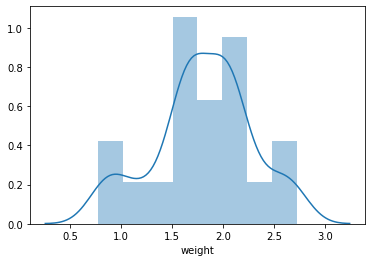

```python
sns.distplot(pidg.weight)
```

### Count version

Dropping the kde plot achieves this.

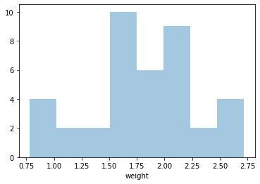

```python
sns.distplot(pidg.weight, kde=False)
```

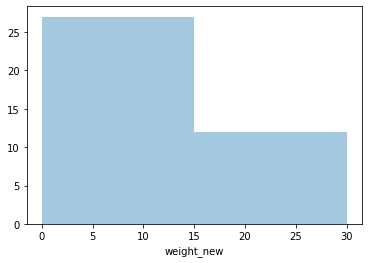

```python
sns.distplot(pidg.weight_new, kde=False)
```

### Log scale

Doesn't work so well for the x axis

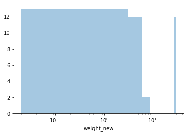

```python
g = sns.distplot(pidg.weight_new, kde=False, bins=10)
g.set_xscale('log')
```

### Log scale

Better to do the log conversion manually and then plot.

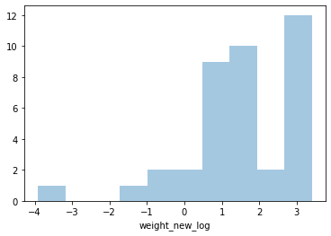

```python
pidg['weight_new_log'] = np.log(pidg['weight_new'])
g = sns.distplot(pidg.weight_new_log, kde=False, bins=10)
```

## Plotting relationships

Most basic is `scatterplot`. Original Pokemon height and weight.

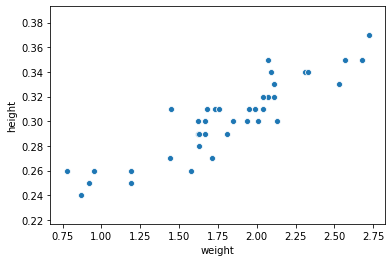

```python
fig = sns.scatterplot(data=pidg, x='weight', y='height')
```

### New height and weight

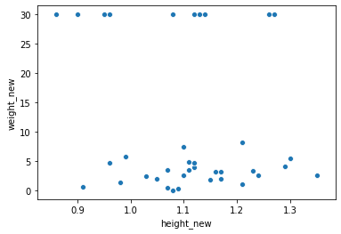

```python
sns.scatterplot(data=pidg, x='height_new', y='weight_new')
```

### With label

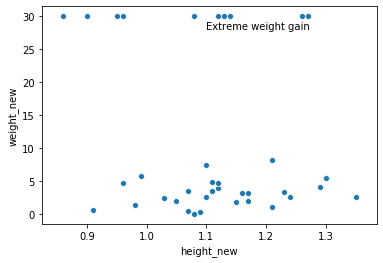

```python
g = sns.scatterplot(data=pidg, x='height_new', y='weight_new')
g.text(1.1, 28, 'Extreme weight gain')
```

## Investigating the weight gain

Create column

```python
pidg['wt_gain'] = pidg['weight_new'] - pidg['weight']
```

### Distribution plot

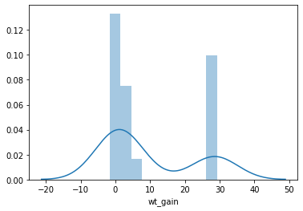

```python
sns.distplot(pidg['wt_gain'], bins=10)
```

Use `describe` to see characteristics of the distribution

```python
pidg['wt_gain'].describe()
```

```
count    39.000000
mean      9.617692
std      12.901387
min      -1.600000
25%       0.275000
50%       1.890000
75%      28.085000
max      29.220000
Name: wt_gain, dtype: float64
```

### Creating a categorical variable from a numeric one

The `cut` function does this. Note that the category labels are pairs that indicate the range.

```python
weight_bins = [-2, 0, 2, 5, 10, 40]
pidg['bin_gain'] = pd.cut(pidg['wt_gain'], weight_bins)
pidg['bin_gain'].head()
```

```
0      (0, 2]
1      (0, 2]
2      (0, 2]
3    (10, 40]
4     (-2, 0]
Name: bin_gain, dtype: category
Categories (5, interval[int64]): [(-2, 0] < (0, 2] < (2, 5] < (5, 10] < (10, 40]]
```

## Divide into new and old

```python
old_cols = ['cp', 'hp', 'weight', 'height', 'power_up_stardust',
       'power_up_candy', 'attack_weak_type',
       'attack_strong_type', 'wt_gain', 'bin_gain']

new_cols = ['cp_new', 'hp_new', 'weight_new', 'height_new',
       'power_up_stardust_new', 'power_up_candy_new',
       'attack_weak_type_new',
       'attack_strong_type_new', 'wt_gain', 'bin_gain']
```

```python
pidg_old = pidg[old_cols].copy()
pidg_new = pidg[new_cols].copy()
```

### Pairplot for the old data

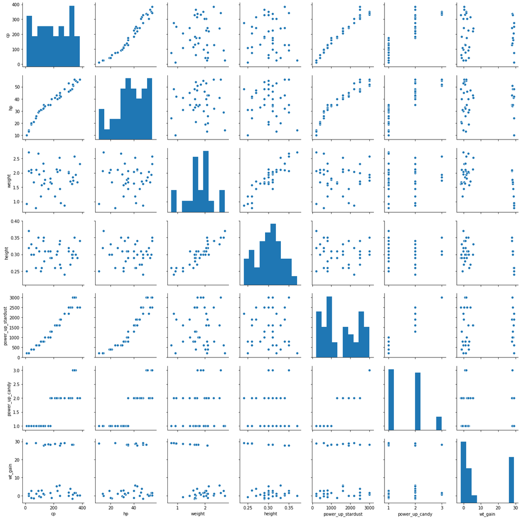

```python
sns.pairplot(pidg_old)
```

## Categorical plots

Using the binned weight gain values. `countplot` gives a histogram.

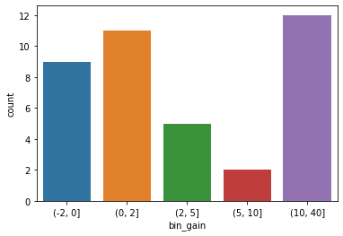

```python
sns.countplot(pidg['bin_gain'])
```

`catplot` with `kind=bar` produces a bar chart of the average y coordinate with 95% confidence interval error bars.

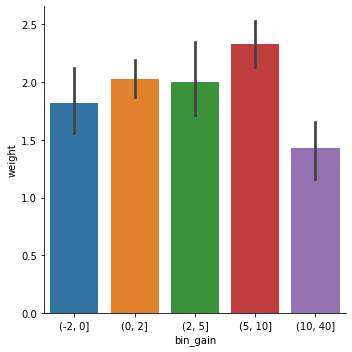

```python
sns.catplot(data=pidg, x='bin_gain', y='weight', kind='bar')
```

Without the `kind` parameter, it produces a strip chart. The jitter is by default.

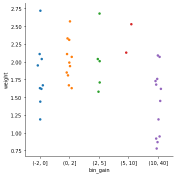

```python
sns.catplot(data=pidg, x='bin_gain', y='weight')
```

### Fancy plot

Side-by-side violin plot. This one has more polished treatment of labels.

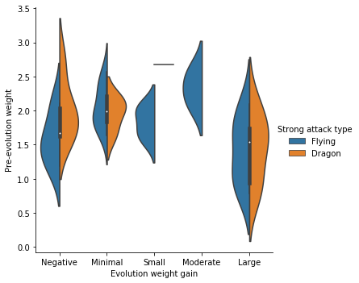

```python
g = sns.catplot(data=pidg, x='bin_gain', y='weight', kind='violin',
            split=True, hue='attack_strong_type', legend=False)
g.ax.set_xlabel('Evolution weight gain')
g.ax.set_ylabel('Pre-evolution weight')
g.ax.set_xticklabels(['Negative', 'Minimal', 'Small', 'Moderate', 'Large'])
g.add_legend(title='Strong attack type')
```

### Saving in a graphics format

```python
g.savefig('pokemon-plot.pdf', format='pdf')
```

### Parallel visualizations

For different strong attack types

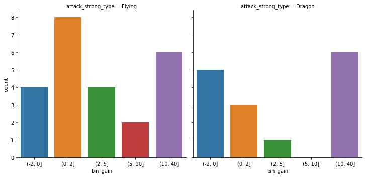

```python
g = sns.catplot(data=pidg, x='bin_gain', kind='count', col='attack_strong_type' )
```

## Generating a heatmap

Looking at the interaction between the weight gain bins and the attack type. First, create a crosstab with the data you want.

```python
tbl = pd.crosstab(pidg['bin_gain'], pidg['attack_strong_type'])
tbl
```

| attack_strong_type bin_gain | Dragon | Flying |
| --- | --- | --- |
| (-2, 0] | 5 | 4 |
| (0, 2] | 3 | 8 |
| (2, 5] | 1 | 4 |
| (5, 10] | 0 | 2 |
| (10, 40] | 6 | 6 |

Then pass to `heatmap`. Darker colors are fewer instances.

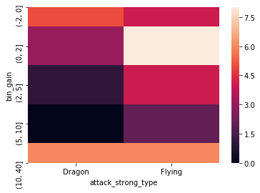

```python
sns.heatmap(tbl)
```

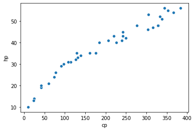

```python
sns.scatterplot(pidg['cp'], pidg['hp'])
```

## Create a new column with different ranges of cp

We could do this with `cut` but this is a different way. We will designate Pokemon with CP less than 100 as 'weak'; those with CP between 100 and 200 as 'moderate'; 200 to 300 as 'strong' and above 300 as 'very strong'.

```python
# This creates the column and gives all values as 'weak'. That's OK because we will next overwrite the values
pidg['StrengthLevel'] = 'weak'
moderate_filter = (pidg.cp > 100) & (pidg.cp <= 200)
pidg.loc[moderate_filter, 'StrengthLevel'] = 'moderate'
strong_filter = (pidg.cp > 200) & (pidg.cp <= 300)
pidg.loc[strong_filter, 'StrengthLevel'] = 'strong'
vstrong_filter = (pidg.cp > 300)
pidg.loc[vstrong_filter, 'StrengthLevel'] = 'very strong'
pidg.StrengthLevel
```

```
0     very strong
1     very strong
2     very strong
3     very strong
4          strong
5        moderate
6            weak
7            weak
8            weak
9        moderate
10       moderate
11    very strong
12       moderate
13           weak
14           weak
```

[output cut: 25 more lines]